# Group 3 Final Report

```r
library(tidyverse)
library(rmarkdown)
library(lubridate)
library(ggthemes)
```

# Introduction

Motor vehicle accidents are devastating and costly. With almost 35,000 people dying each year in the United States due to crashes that cost over $75 billion, there has to be something we can do to help. We focused our analysis on identifying trends that can be used to help minimize crashes. Our questions were:

- What are common features of motor vehicle crashes?
- What can be done to mitigate crashes?
- How does Iowa compare to the nation as a whole?

These questions focus on our goal of reducing the amount of crashes. Based on our analysis we’ll be aiming to come up with ideas like policy changes at the state or national level, and better education of what increases chances of crashes.

How we obtained and cleaned the dataset:

To clean our datasets we removed null values and renamed some columns to simpler names so that the columns were easier to work with. We also converted the “Date” column into the Date format, so that for the time series we could easily sort the data by year. Some challenges we had with this dataset was the size of it being about 2 GB, well above the github limit, and figuring out the best way to use some of the columns like severity. Some variables, such as severity, were not clearly defined and interpreting our results was sometimes difficult.

## Requirements

### Libraries

- tidyverse
- lubridate
- mapproj
- ggthemes

### Data

- US_Accidents_Dec20.csv: Previously accessible via Kaggle, but has been updated since then. We uploaded the version we used so that the same one can be downloaded and moved to the working directory to run this Rmd and get the same results: https://iastate.box.com/s/3y1kikk2c6zpzhgv6t5g8kngc1ylupuk
- us_accidents_df.csv: The zipped version of this was small enough to be uploaded to GitHub. Can extract this zip and move the file to the working directory.
- Other datasets used were small and included directly in the repo, so no need to extract.

# Overview of U.S. Motor Accidents

The dataset spans from 2016 to 2020. We first process the data into a form that allows us to summarize some aspects of it more easily.

We also use a chart to convert the state abbreviations to state names as well as a dataset contains census population counts.

```r
#acc_raw <- read_csv('US_Accidents_Dec20.csv')

# TEMP
acc_raw <- read_csv('US_Accidents_Sample.csv')

census_raw <- read.csv('census2010-2019.csv')
states <- map_data('state')
abv <- read.csv('state_abbrvs.csv', fileEncoding="UTF-8-BOM")


# === Census Preprocessing ===
# Separate area into city and state, summarize population per state in each year
census <- census_raw %>%
  mutate(across(Census:X2019, function(x){as.numeric(gsub(",", "", x))})) %>%
  separate(Geographic.Area, sep=', ', into=c('City', 'region')) %>%
  group_by(region) %>%
  summarize(
    `2016`=sum(X2016),
    `2017`=sum(X2017),
    `2018`=sum(X2018),
    `2019`=sum(X2019)
  ) %>%
  pivot_longer(`2016`:`2019`, names_to='Year', values_to='Population') %>%
  mutate(Year=as.numeric(Year), State=region) %>%
  select(-region)


# === Accidents Preprocssing ===
# Convert state code to state name, format time, select only the columns needed
acc <- acc_raw %>%
  mutate(Code=State) %>%
  select(-State) %>%
  left_join(abv, by='Code') %>%
  select(Start_Time, Start_Lat, Start_Lng, State) %>%
  mutate(State=tolower(State), Time=ymd_hms(Start_Time)) %>%
  select(-Start_Time) %>%
  mutate(State=str_to_title(State))

states <- states %>%
  mutate(State=str_to_title(region)) %>%
  select(-region, -subregion)
```

First, we can visualize the accidents all over the U.S. by plotting them as points over a map of the U.S.

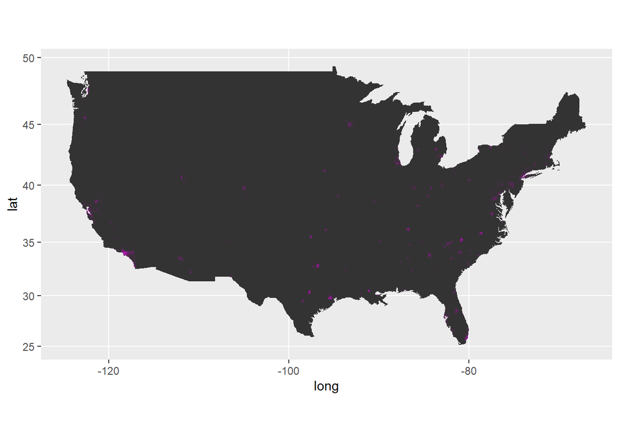

```r
states %>% ggplot(aes(x=long, y=lat)) +
  geom_polygon(aes(group=group)) +
  geom_point(data=acc, aes(x=Start_Lng, y=Start_Lat), color='magenta2', size=0.02, alpha=0.02) +
  coord_map()
```

We can see that accidents are concentrated in cities and also on roads, since of course those are locations where cars drive the most, and therefore where accidents are most likely to occur.

However, we may want to instead see the total accidents by state. We can do so using a choropleth map.

Below is a choropleth map showing the total accidents over 2016-2020 by state.

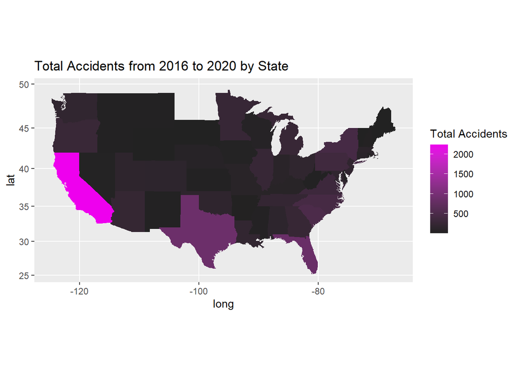

```r
acc_states <- acc %>% group_by(State) %>% summarize(total_accidents=n())

acc_map <- acc_states %>% left_join(states, by='State')

ggplot(acc_map, aes(x=long, y=lat)) +
  geom_polygon(aes(group=group, fill=total_accidents)) +
  coord_map() + labs(fill='Total Accidents') +
  scale_fill_gradient(low="#222222", high="magenta2") +
  ggtitle('Total Accidents from 2016 to 2020 by State')
```

Above we can see that clearly the states with the highest populations (California, Texas, Florida) have the most accidents total, which makes sense. It might be more insightful to instead look at the per capita accident rates.

```r
acc2019 <- acc %>% filter(year(Time)==2019)

census2019 <- census %>% filter(Year==2019)

acc2019 <- acc2019 %>% left_join(census2019, by='State')

acc2019_states <- acc2019 %>%
  group_by(State) %>%
  summarize(total_accidents=n(), population=first(Population), per1000=n()*1000/first(Population))

acc2019_states %>% paged_table
```

|  | State | total_accidents | population | per1000 |
| --- | --- | --- | --- | --- |
| 1 | Alabama | 40 | 2998987 | 0.0133378371 |
| 2 | Arizona | 78 | 5791407 | 0.0134682297 |
| 3 | California | 545 | 32965607 | 0.0165323818 |
| 4 | Colorado | 49 | 4279051 | 0.0114511372 |
| 5 | Connecticut | 15 | 1379443 | 0.0108739542 |
| 6 | Delaware | 4 | 276116 | 0.0144866650 |
| 7 | District Of Columbia | 5 | NA | NA |
| 8 | Florida | 140 | 10766975 | 0.0130027236 |
| 9 | Georgia | 49 | 4685332 | 0.0104581703 |
| 10 | Idaho | 2 | 1257628 | 0.0015902954 |

[output cut: 34 more lines]

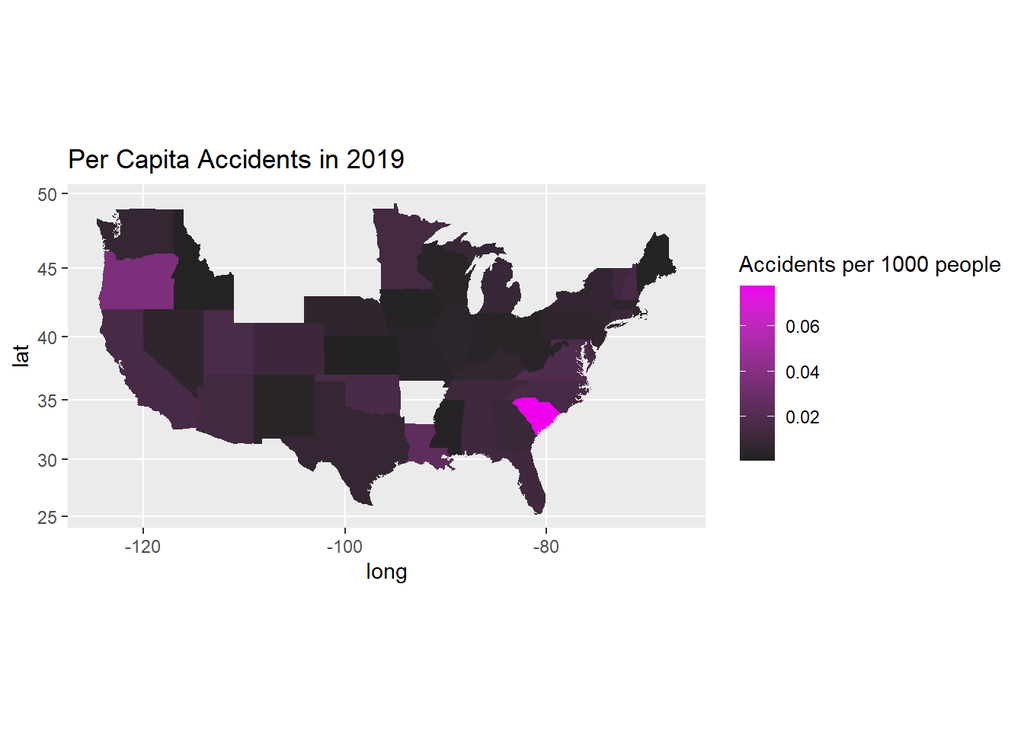

```r
acc_map_capita <- acc2019_states %>% left_join(states, by=c('State'))

ggplot(acc_map_capita, aes(x=long, y=lat)) +
  geom_polygon(aes(group=group, fill=per1000)) +
  coord_map() + ggtitle('Per Capita Accidents in 2019') +
  labs(fill='Accidents per 1000 people') +
  scale_fill_gradient(low="#222222", high="magenta2")
```

Interestingly, we can see that South Carolina and Oregon seem to have the highest per capita accident rates.

We can further investigate this with the use of a bar chart.

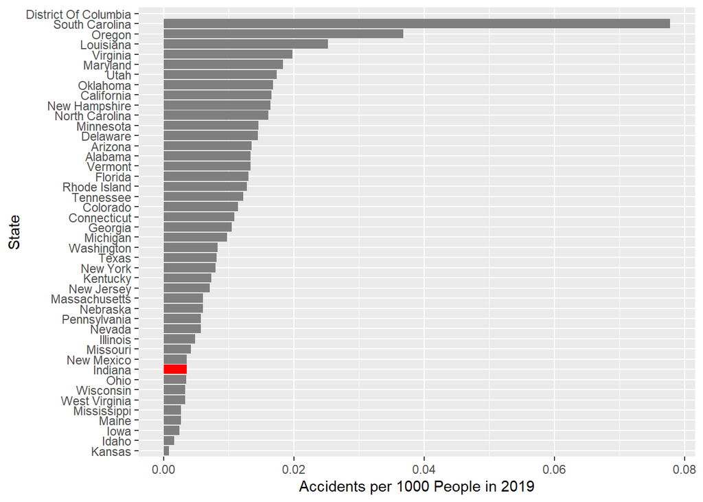

```r
col <- c(rep(c('grey50'), 8), c('red'), rep(c('grey50'), 40))

acc2019_states %>%
  mutate(State=str_to_title(State)) %>%
  arrange(per1000) %>%
  mutate(State=factor(State, levels=State)) %>%
  ggplot(aes(x=State, weight=per1000, fill=State)) + geom_bar() + coord_flip() +
  scale_fill_manual(values=col) +
  ylab('Accidents per 1000 People in 2019') +
  theme(legend.position = "none")
```

We can see that South Carolina has approximately double the accident rate of Oregon.

It’s difficult to attribute this to some cause. It could be some problem with South Carolina’s infrastructure or driving education but that lies outside the scope of this project.

```r
suppressWarnings(library(dplyr))
suppressWarnings(library(data.table))
```

```r
suppressWarnings(library(ggplot2))
suppressWarnings(library(tidyverse))
```

```r
data2 <- read_csv('genderAndAgeData.csv')
data2 <- na.omit(data2)
data2 <- data2 %>% rename(fatals = 'Fatalities in crash')

f1 <- data2 %>% group_by(Age, Gender) %>% summarize(count = n()) %>% arrange(desc(count))
```

## Accidents Given Age

The graph on below shows the number of accidents by age and the two different colors are for men and women. Men consistently get in 2-3 times more accidents from ages 18-75.

Younger people in general got in a lot more accidents. This is likely due to lack of experience and getting distracted while driving. Common distractions are phones and friends in the car, so teenagers and young adults learning to balance that while driving can be challenging.

The biggest drop offs are in the late 20’s to early 40’s. This could be due to maturing and becoming more responsible drivers over time. There is also a drop off at 60 and 75 years old which is likely due people driving less as they get older and retire.

I was interested in some of these numbers so I did some research and found that on average men drive 40% more miles per year than women, which would explain the general idea that men get in more accidents, but to see 2-3 times more accidents means there are still other factors playing a major role in why men get into more accidents.

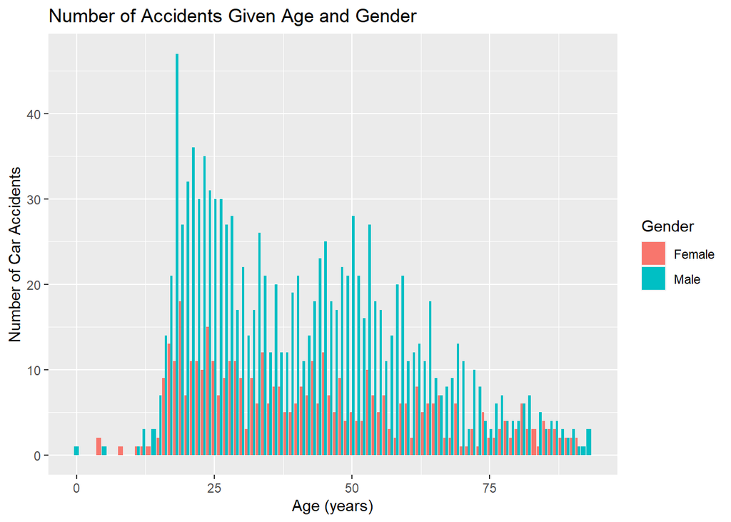

```r
ggplot(f1, aes(x=Age, y = count, fill = Gender)) + geom_bar(stat="identity", position = "dodge") + xlab("Age (years)") + ylab("Number of Car Accidents") + ggtitle("Number of Accidents Given Age and Gender")
```

```r
data2$dates <- as.Date(data2$'Crash Date', "%m/%d/%y")
temp <- data2
temp$weekday <- weekdays(temp$dates)
temp <- temp

temp$group1 <- ifelse(temp$Age < 41, "Under35", "35andUp")
temp2 <- temp %>% group_by(weekday, Gender) %>% filter(group1 == "Under35") %>% summarize(N = n()) %>% arrange(desc(N))
temp3 <- temp %>% group_by(weekday, Gender) %>% filter(group1 == "35andUp") %>% summarize(N = n()) %>% arrange(desc(N))
```

## Accidents with Age and Gender

Below are two graphs that show the number of car accidents by day of the week among men and women. The first graph is for Under 41 years old and the second graph is for 41 and older. The average age of someone in an accident in this data set was 41 so that is why I choose to use that as my cutoff in determining the groups.

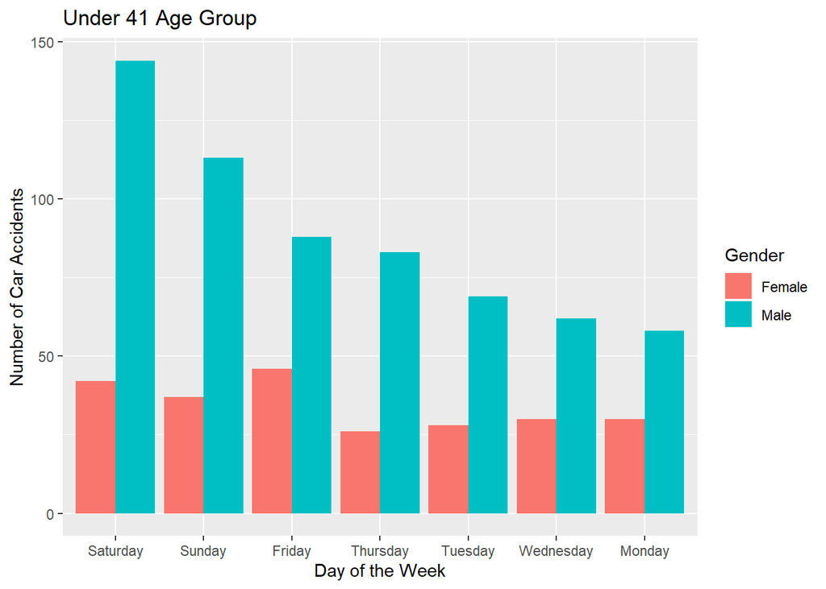

```r
ggplot(temp2, aes(x = reorder(weekday, -N), y = N, fill = Gender)) + geom_bar(stat = "identity", position = "dodge") + xlab("Day of the Week") + ylab("Number of Car Accidents") + ggtitle("Under 41 Age Group")
```

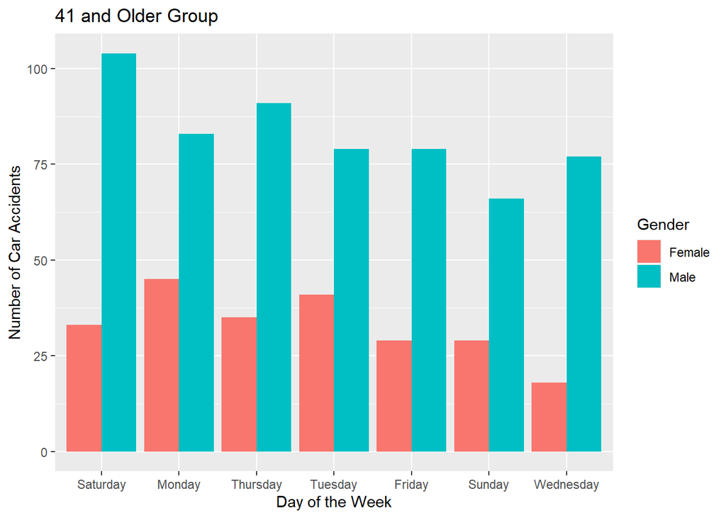

```r
ggplot(temp3, aes(x = reorder(weekday, -N), y = N, fill = Gender)) + geom_bar(stat = "identity", position = "dodge") + xlab("Day of the Week") + ylab("Number of Car Accidents") + ggtitle("41 and Older Group")
```

# Accidents in Iowa

### Load Data Frames

```r
census <- read_csv("census.csv")%>%
  filter(STNAME == "Iowa", PRIMGEO_FLAG == 0, FUNCSTAT == "A")
iowa <- read_csv("US_Accidents_Dec20.csv", col_types = cols(End_Lat=col_character(),End_Lng=col_character()))%>%
  select(State, Severity, Start_Time, Start_Lat, Start_Lng, `Wind_Speed(mph)`,Weather_Condition)%>%
  filter(State %in% "IA")

county <- map_data("county")
```

### Plot Accidents in Iowa

We also decided to look at accidents close to home. Evident in the map below, accidents in Iowa cluster in areas we know to be the most congested; namely, many accidents occur around Des Moines and along I-35 and I-80. Additionally, Iowa’s northwestern corner appears to exhibit disproportionately many severe accidents relative to non-severe ones.

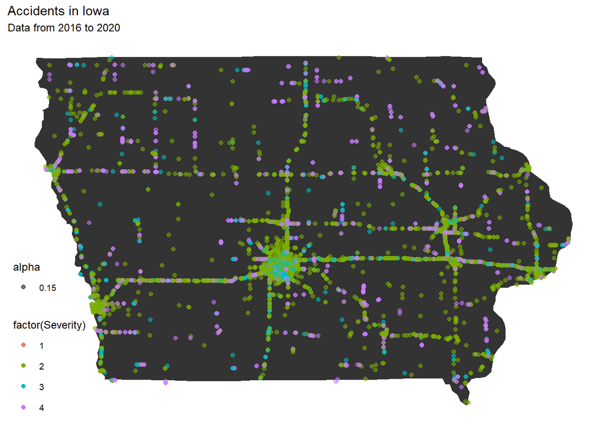

```r
iowacounties<- county%>%
  filter(region %in% "iowa")

p<-ggplot(iowacounties, aes(x=long, y=lat))+geom_polygon(aes(group=group))
p<-p+geom_point(data=iowa, aes(x=Start_Lng, y=Start_Lat, color=factor(Severity), alpha=0.15))
p<-p+labs(title="Accidents in Iowa", subtitle="Data from 2016 to 2020")+theme_map()
p
```

### Plot Severity by Wind Speed and Weather Type

Nearly any Iowan can testify to the hazards of slippery weather. However, we sought to quantify weather’s influence on accident frequency and severity by observing crashes recorded in Iowa over the past five years.

```r
iowa1<-iowa%>%
  select(`Wind_Speed(mph)`,Severity, `Weather_Condition`)%>%
  na.omit()%>%
  group_by(Weather_Condition)%>%
  summarize(`Average Severity` = mean(Severity), `Average Wind Speed (mph)` = mean(`Wind_Speed(mph)`), n=n())%>%
  filter(n>15)
```

Slippery conditions are generally associated with the most severe crashes. Accidents in ‘light freezing rain’ were the most severe by a considerable margin, followed by snow, rain, and light thunderstorms.

Based on the results, Iowans should limit driving on days with lots of precipitation and reduce their speeds.

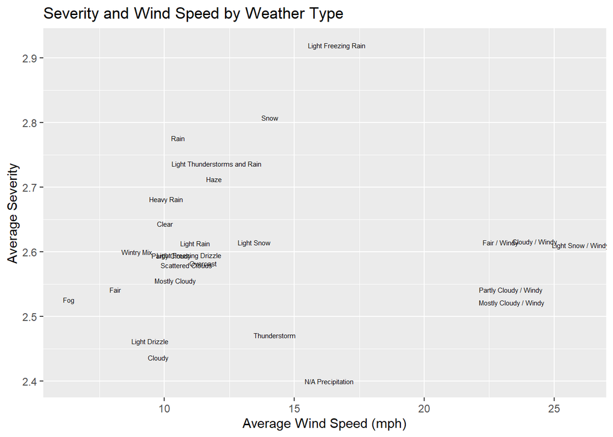

```r
ggplot(iowa1, aes(y=`Average Severity`, x=`Average Wind Speed (mph)`))+geom_text(aes(label=`Weather_Condition`), size=2)+labs(title="Severity and Wind Speed by Weather Type")
```

```r
# FIXME
#iowa %>%
#  mutate(Day = wday(Start_Time, label=TRUE, abbr=FALSE))%>%
#  group_by(Day)%>%
#  ggplot(aes(x=Day))+geom_bar()+labs(title="Accidents in Iowa by Weekday")
```

# Effects of Weather Conditions on Accidents

```r
accidents <- read.csv("us_accidents_df.csv", stringsAsFactors = FALSE)
```

First, lets make a frequency table for the variable severity. Table shows us that mode of the variable severity is 2. We can say there are few severity factors of 1 and 4 but 4 is being more common than 1.

### A Frequency Table for Severity

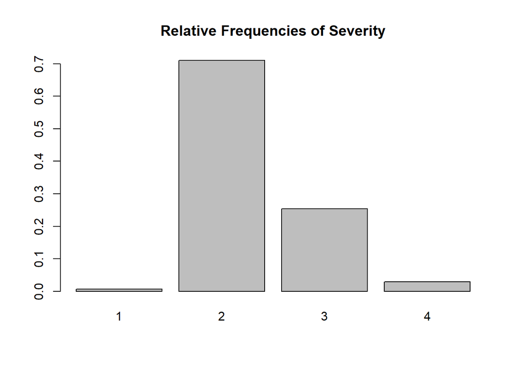

```r
severity_count <- c(sum(accidents$Severity==1), sum(accidents$Severity==2), sum(accidents$Severity==3), sum(accidents$Severity==4))
freq <- severity_count/sum(severity_count )
barplot(freq, names.arg = 1:4, main = "Relative Frequencies of Severity")
```

Our histogram shows that reported temperature at 0 degrees Fahrenheit, there are few accidents since this weather is not very common in the US.

As the temperature starts to increase, the number of accidents also increase mainly because there are more people out when it is warmer. When the temperature increase from there, accidents starts going down since less people are out due to weather being too hot

### Analyzing Temperature

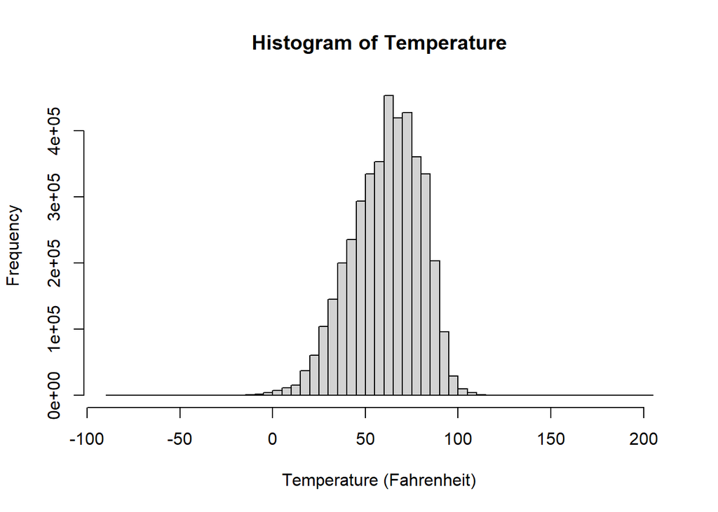

```r
hist(accidents$Temperature.F., breaks=seq(-90, 205, 5), xlab = "Temperature (Fahrenheit)", main = "Histogram of Temperature")
```

Finally lets look the weather conditions by severity. There are many different weather conditions reported but we are going to only visualize the ones which caused more than 100 accidents.

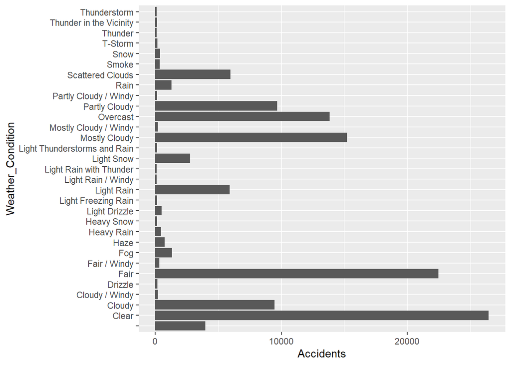

```r
weather_cond<-table(accidents$Weather_Condition, accidents$Severity)

weather_cond_df<-data.frame(weather_cond)
colnames(weather_cond_df)<-c("Weather_Condition","Severity","Accidents")
weather_cond_df <- weather_cond_df %>%
  filter(Severity == 4) %>%
  arrange(desc(Accidents)) %>%
  filter(Accidents > 100)

b <- ggplot(data=weather_cond_df, aes(x=Weather_Condition, y=Accidents)) + geom_bar(stat="identity") + coord_flip()
b
```

As our analysis shows, we conclude that weather condition does not have a strong impact on accident severity.

# Daily Accidents Time Series

```r
acc = read.csv("US_Accidents_Dec20.csv")
```

```r
acc = separate(acc, Start_Time, into = c("Date", "Time"), sep = " ")
```

```r
acc$Date = ymd(acc$Date)
```

```r
acc$Year = year(acc$Date)
acc$Month = month(acc$Date)
acc$Day = day(acc$Date)
```

```r
daily_acc = acc %>% group_by(Date) %>% summarise(n = n()) %>% mutate(year = year(Date))
```

Here we had to separate the Start_Time column into time and date, then convert the date into Date format using the lubridate library.

### 2016-2020 Daily Accidents in America

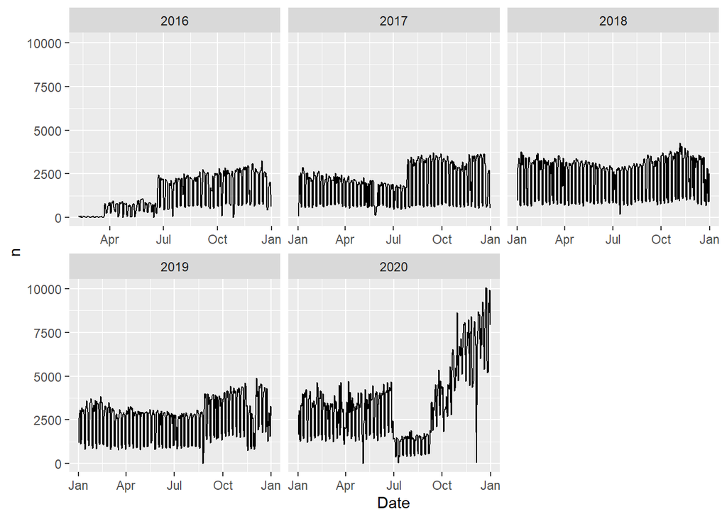

```r
daily_acc %>% ggplot(aes(x=Date, y=n)) + geom_line() + facet_wrap(~year, scales = "free_x") + scale_x_date(date_labels = "%b")
```

This is a time series of the number of daily accidents. We can see from this graph that the number of accidents remains fairly consistent over time, with only slight jumps, probably caused by adding more ways of obtaining accident data. 2020 is the year that is much different from the rest, with the number of accidents dipping during the pandemic, and then rising higher than the pre-pandemic numbers.

### 2020 Daily Accidents in America

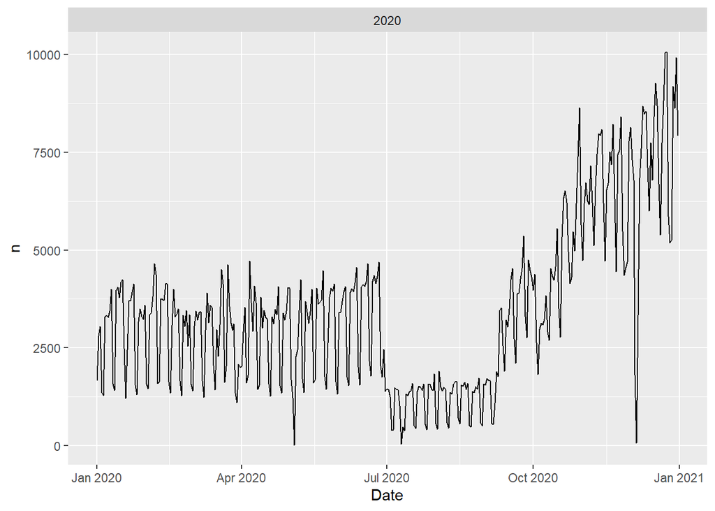

```r
daily_acc %>% filter(year == 2020) %>% ggplot(aes(x=Date, y=n)) + geom_line() + facet_wrap(~year, scales = "free_x")
```

Here we can see a better look of what happened in 2020. This graph, along with some research, tells us that driving speeds increased during the pandemic, which led to more accidents once more cars returned to the road.

### Total Accidents by Month

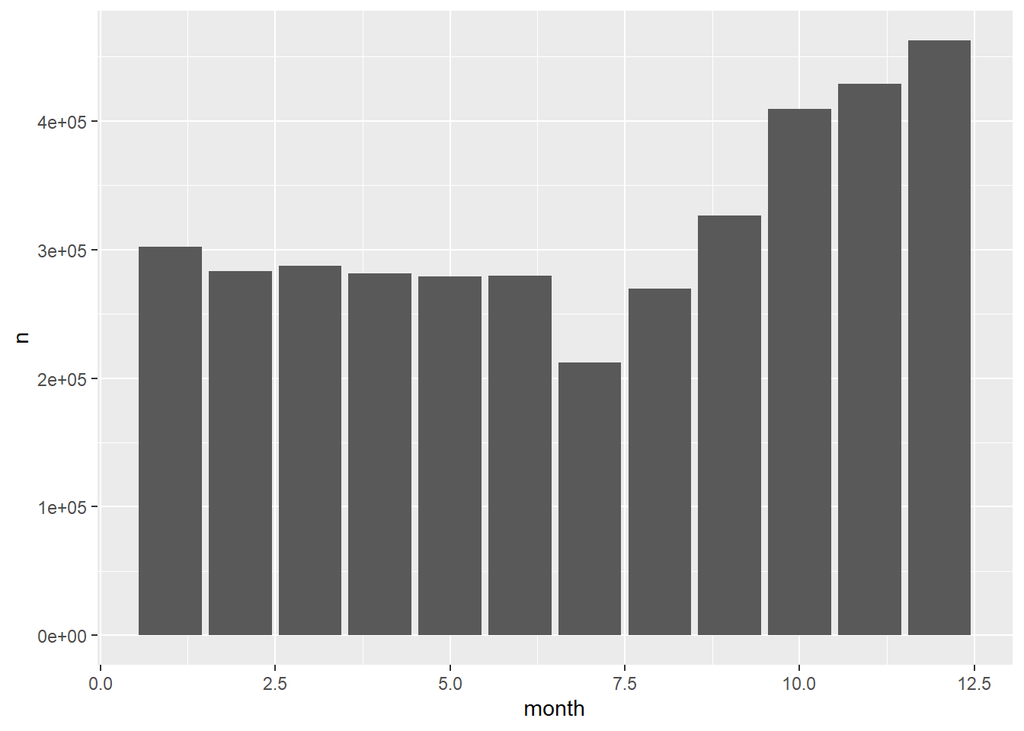

```r
daily_acc %>% filter(year != 2016) %>% group_by(month(Date)) %>% summarise(n=sum(n)) %>% rename("month" = "month(Date)") %>% ggplot(aes(x=month, y=n)) + geom_bar(stat = "identity")
```

This graph shows us that July is the month with the fewest accidents from 2017 to 2020, and December is the month with the most. This is all due to the numbers in 2020, because the months were pretty even until then.

### 2016-2020 Severe Accidents in America

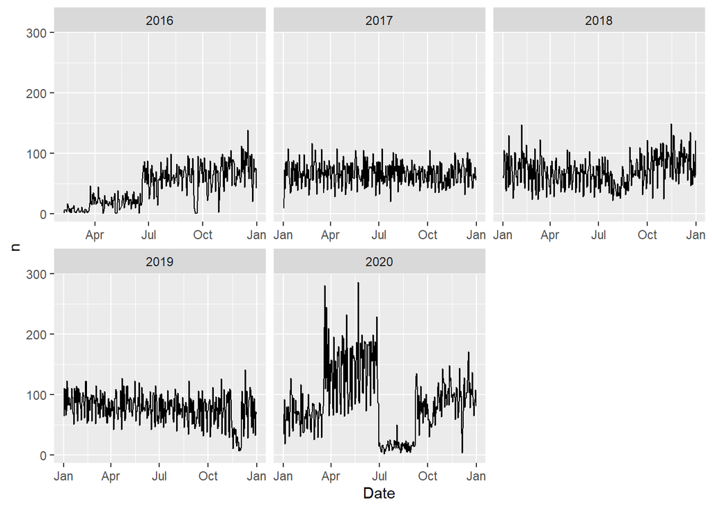

```r
acc %>% filter(Severity==4) %>% group_by(Date) %>% summarise(n = n()) %>% mutate(year = year(Date)) %>% ggplot(aes(x=Date, y=n)) + geom_line() + facet_wrap(~year, scales = "free_x") + scale_x_date(date_labels = "%b")
```

This is a look at the severe accidents (accidents with the highest severity score) per day. Here we can see that the numbers remained the same for the most part until the pandemic hit, when numbers then spiked.

### 2020 Severe Accidents in America

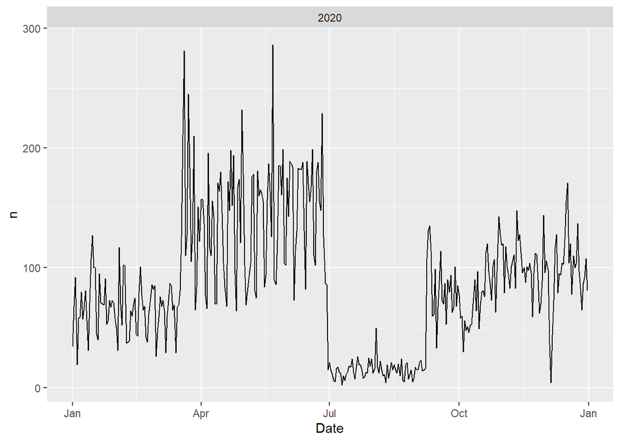

```r
acc %>% filter(Severity==4, Year==2020) %>% group_by(Date) %>% summarise(n = n()) %>% mutate(year = year(Date)) %>% ggplot(aes(x=Date, y=n)) + geom_line() + facet_wrap(~year, scales = "free_x") + scale_x_date(date_labels = "%b")
```

Here is a closer look at the year 2020, and we can see the large spike at the start of the pandemic. Research found that driving speeds increased with fewer cars on the road, so those higher speeds might have led to more severe accidents.

### 2016-2020 Accidents in Iowa

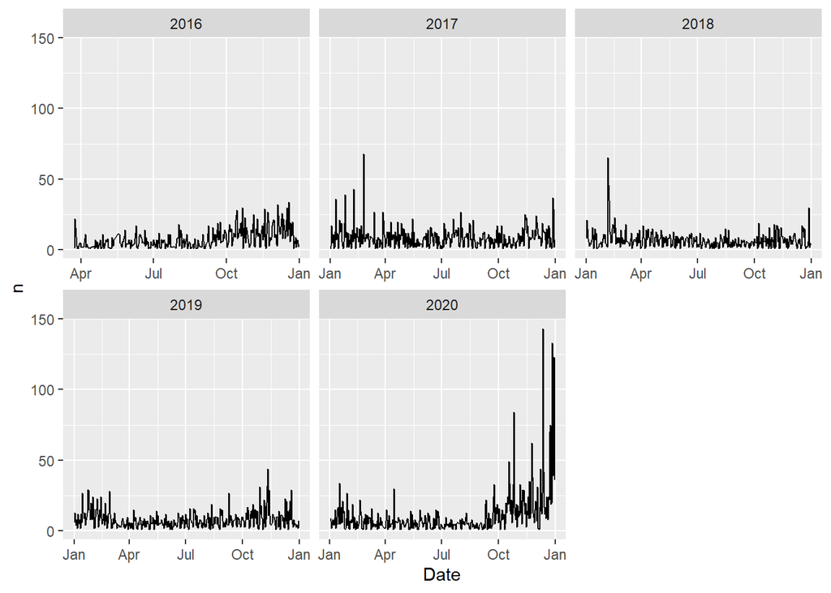

```r
acc %>% filter(State=="IA") %>% group_by(Date) %>% summarise(n = n()) %>% mutate(year = year(Date)) %>% ggplot(aes(x=Date, y=n)) + geom_line() + facet_wrap(~year, scales = "free_x") + scale_x_date(date_labels = "%b")
```

This chart is a look at the number of daily accidents in the state of Iowa. We can see from this graph that the drivers in Iowa performed much like the rest of the United States. There was a large spike in the number of accidents at the end of 2020.

### 2020 Accidents in Iowa

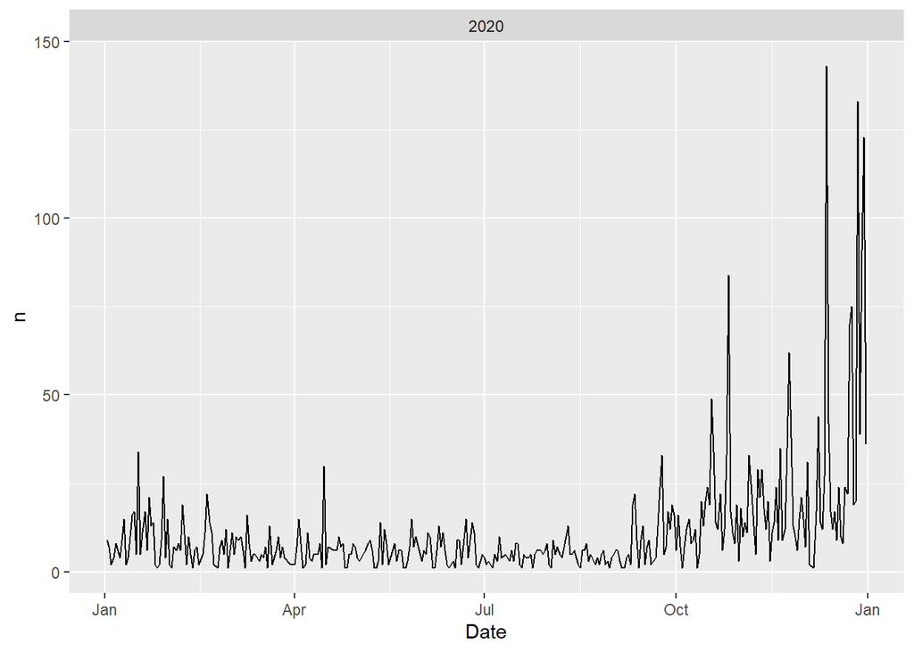

```r
acc %>% filter(Year == 2020, State=="IA") %>% group_by(Date) %>% summarise(n = n()) %>% mutate(year = year(Date)) %>% ggplot(aes(x=Date, y=n)) + geom_line() + facet_wrap(~year, scales = "free_x") + scale_x_date(date_labels = "%b")
```

Looking closer at 2020, we can see that spike at the end of 2020. This, along with the prior graph, tells us that the driving behavior of Iowans matches the driving behavior of the rest of America.

## Conclusion:

Although motor vehicle crashes are calamitous and will remain a problem into the future, our report reveals key signs of hope. Namely, we identified disparities in the number and severity of crashes across locations, suggesting states with very high crash rates may be able to reduce their crash rate through policy intervention.

## Contribution Statements:

Anders: My analysis explored the accident data over the U.S. as a whole. I investigated in which areas and states accidents were most common, as well as the per-capita accident rates. I also compared Iowa’s accident rate to the rest of the states to see how much room for improvement Iowa has. I used a layered map, choropleth maps, as well as bar charts to demonstrate my findings in these areas.

Eric: My analysis focused on the changes in number of daily accidents over the years. This analysis focused heavily on the impact of COVID-19, because the pandemic had a large impact on traffic, and therefore the number of accidents. I also contributed to the team report and presentation.

Murat: My analysis primarily focused on how weather conditions affected accidents by looking at the variable severity. I contributed to the team report and presentation. I also combined/edited the videos from my groupmates and I narrated the introduction part of the presentation.

Ryan: I focused my analysis on looking at car accidents among men and women. I compared the totals from different ages of men and women, as well as comparing the totals among men and women by the different days of the week. I also worked on the presentation and team report.